# Practica 9: Reconstrucción Filogenética

Última actualización:

15 de mayo de 2026

# Introducción

Aunque existen muy buenos programas para inferir filogenias fuera del entorno de R (es decir, para el terminal de Bash), utilizar las herramientas en R tiene la ventaja de poder representar los árboles, manipularlos y extraer información de ellos con toda la flexibilidad que permite un lenguaje de programación. Otros programas como RAxML o IQtree producirían los resultados en forma de archivos de texto con formato Newick o NEXUS. En R, los árboles serán objetos de clase `phylo`, que pueden también ser exportados como archivos de texto con formato Newick con la función `write.tree()` del paquete `ape`. Este paquete será cargado automáticamente cuando carguemos el paquete phangorn, que proporciona las principales funciones para inferencia filogenética

# Objetivos

Obtener una filogenia calibrada de homininos y algunos primates, a partir de secuencias mitocondriales.

# Datos

Pinchando aquí: https://aulavirtual.uv.es/pluginfile.php/6009204/mod_resource/content/3/mtDNA.fasta; descargaréis un alineamiento en formato FASTA de 42 cromosomas mitocondriales completos de: un gorila, cuatro chimpancés, cuatro bonobos, un Homo heidelbergensis (de hace unos 400000 años), 4 humanos denisovanos (de hace entre 30000 y 110000 años), 19 humanos neandertales (de hace entre 30000 y 180000 años) y 9 humanos anatómicamente modernos (actuales). Encontréis también el archivo en el aula virtual, con el nombre mtDNA.fasta, por si el enlace no funciona. Antes de analizarlos, debemos instalar el paquete phangorn con el comando `install.packages("phangorn")` en nuestra consola de R.

Guardamos el archivo mtDNA.fasta en la carpeta de datos. Una vez hecho, la analizamos con la librería phangorn:

```r
PBioinfo <- system("curr=$PWD; while [ \"$curr\" != \"/\" ] && [ -z \"$(ls \"$curr\"/*.Rproj 2>/dev/null)\" ]; do curr=$(dirname \"$curr\"); done; echo \"$curr\"", intern = TRUE)

setwd(PBioinfo)

library(phangorn)
mtdna <- read.phyDat('data/Practica_09/mtDNA.fasta', format = 'fasta')
```

Después de ejecutar el bloque anterior, habrás cargado los datos en el objeto de clase phyDat llamado mtdna. Puedes usar la consola de R para echarle un vistazo, por ejemplo con la función glance() o incluso para generar una imagen del alineamiento con image(). Si tienes instalado el paquete Biostrings (de Bioconductor), puedes crear un objeto de classe DNAStringSet con as.StringSet(mtDNA), al que se le pueden aplicar muchas otras funciones, pero no es lo que vamos a hacer ahora.

**NotaEjercicio 1**

¿Puedes confirmar el número de secuencias? ¿Qué longitud tiene el alineamiento? ¿Qué función usarías para extraer los nombres de las secuencias?

**NotaSolución 1**

1. Para confirmar el número de secuencias, podemos usar

```r
length(mtdna)
```

```
[1] 42
```

Lo que nos da que tenemos un total de 42 secuencias diferentes. Esto es lo que nos daban en los datos del archivo, así que está confirmado.

2. Esta pregunta depende de que es lo que quieras. Según gemini, los objetos `phyDat` colapsan los sitios repetidos para ahorrar espacio, por lo que hacer un ncol() lo único que nos diría es la cantidad de secuencias no repetidas. Para obtener el alineamiento total, tenemos que sumar todo los pesos:

```r
sum(attr(mtdna, "weight"))
```

```
[1] 16603
```

```r
attr(mtdna, "nr")
```

```
[1] 974
```

3. Por último, si queremos obtener los nombres de las secuencias, solo tenemos que poner la función:

```r
names(mtdna)
```

```
 [1] "G.gorilla_D38114"            "P.troglodytes_JF727212"
 [3] "P.troglodytes_JN191207"      "P.troglodytes_JF727168"
 [5] "P.troglodytes_HM068590"      "P.paniscus_KX211934"
 [7] "P.paniscus_KX211928"         "P.paniscus_GU189658"
 [9] "P.paniscus_GU189664"         "H.heidelbergensis_NC_023100"
[11] "H.s.denisova_NC_013993"      "H.s.denisova_FR695060"
[13] "H.s.denisova_KX663333"       "H.s.denisova_KT780370"
[15] "H.s.neandertal_KX198085"     "H.s.neandertal_KX198086"
[17] "H.s.neandertal_MG025538"     "H.s.neandertal_NC_011137"
[19] "H.s.neandertal_FM865409"     "H.s.neandertal_FM865407"
[21] "H.s.neandertal_KX198088"     "H.s.neandertal_KX198083"
[23] "H.s.neandertal_MG025540"     "H.s.neandertal_MG025536"
[25] "H.s.neandertal_MG025537"     "H.s.neandertal_KX198087"
[27] "H.s.neandertal_KX198082"     "H.s.neandertal_FM865408"
[29] "H.s.neandertal_KU131206"     "H.s.neandertal_KF982693"
[31] "H.s.neandertal_FM865411"     "H.s.neandertal_KY751400"
[33] "H.s.neandertal_MK033602"     "H.s.modern_EU092846"
[35] "H.s.modern_EU092665"         "H.s.modern_JQ045086"
[37] "H.s.modern_DQ779927"         "H.s.modern_DQ779932"
[39] "H.s.modern_AP008640"         "H.s.modern_AY495317"
[41] "H.s.modern_J01415"           "H.s.modern_FJ236981"
```

y nos responde con una lista de todos los nombres junto con su código alfanumérico.

# Árboles basados en distancias

Los árboles NJ y UPGMA pueden proporcionar una idea rápida de cómo podría ser la relación filogenética entre las secuencias. Como métodos basados en distancias que son, necesitamos calcular primero las distancias. Podemos hacerlo en el mismo paso en el que generamos el árbol: `nj(dist.ml(mtdna))`. O bien, podemos hacerlo en dos pasos: guardar la matriz de distancias en un objeto de clase dist, y después generar los árboles.

La función `dist.ml()` (de phangorn) solo ofrece un par de modelos de evolución de nucleótidos para estimar distancias: F81 y JC69 (ofrece 17 modelos para proteínas). La función `dist.dna()` de ape (que no se aplica sobre objetos phyDat, sino DNAbin) ofrece algunas opciones más. Pero en el fondo, los métodos NJ y UPGMA son sólo heurísticos rápidos, con los que no hace falta usar distancias de alta precisión.

```r
distancias <- dist.ml(mtdna, model = 'F81')
mt_nj    <- NJ(distancias)
mt_upgma <- upgma(distancias)
```

**NotaEjercicio 2**

1. De qué clase son los objetos mt_nj y mt_upgma?
2. Consulta la estructura de estos objetos (str(mt_nj)).
3. Represéntalos gráficamente (plot(mt_nj)) y consulta la ayuda de la función plot.phylo() para saber qué opciones de representación gráfica tienes.
4. Para qué sirven las funciones add.scale.bar() y axisPhylo()?

**NotaSolución 2**

1. Para averiguarlo, usamos la función class:

```r
class(mt_nj)
```

```
[1] "phylo"
```

```r
class(mt_upgma)
```

```
[1] "phylo"
```

y obtenemos que pertenecen a la clase `phylo`.

```r
str(mt_nj)
```

```
List of 4
 $ edge       : int [1:81, 1:2] 47 47 54 54 53 53 52 52 51 51 ...
 $ edge.length: num [1:81] 6.03e-05 5.20e-08 -4.37e-08 4.37e-08 8.51e-08 ...
 $ tip.label  : chr [1:42] "G.gorilla_D38114" "P.troglodytes_JF727212" "P.troglodytes_JN191207" "P.troglodytes_JF727168" ...
 $ Nnode      : int 40
 - attr(*, "class")= chr "phylo"
 - attr(*, "order")= chr "postorder"
```

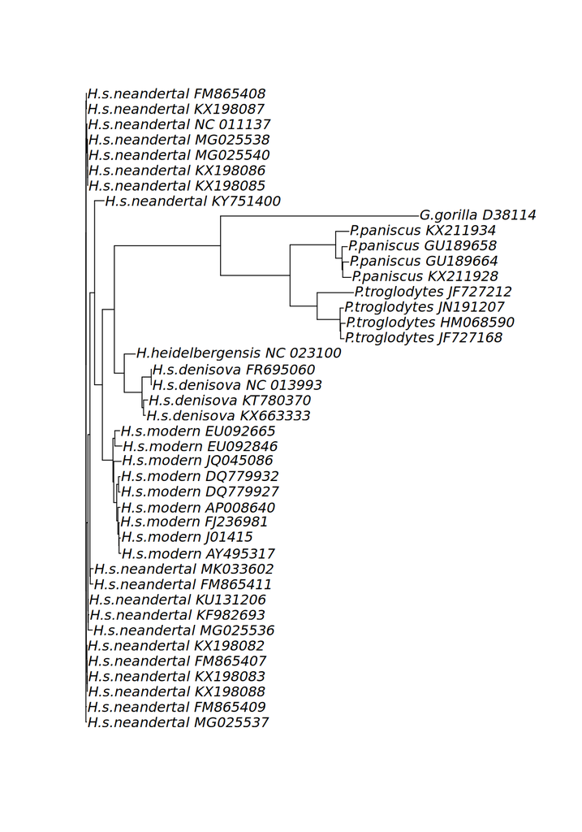

```r
plot.phylo(mt_nj)
```

4. `add.scale.bar()` nos sirve para graficar una linea que representa una distancia genética concreta en nuestro arbol. De esta forma, podemos comparar más o menos a simple vista distancias genéticas sin equivocarnos. Es lo mismo que se usan en las imagenes microscopicas por ejemplo para dar contexto de los tamaños. Por otro lado, axisPhylo() nos da una regla a lo largo de todo el arbol, mostrandonos la longitud acumulada desde la raiz hasta el final de la ultima rama y permitiendonos extrapolar mucho más fácilmente una divergencia concreta.

# Enraizar

```r
mt_nj_rooted <- root(mt_nj, node = 75)
```

## Con un outgroup

La numeración de los nodos internos siempre sigue a la de las hojas (o puntas) del árbol. El orden es caprichoso y después de enraizar, lo que era el 75 en mt_nj ahora será el 43 en mt_nj_rooted, liandonos más. Para garantizar que el enraizado no depende de la numeración, lo más seguro es usar el nombre del outgroup:

```r
mt_nj_rooted <- root(mt_nj, outgroup = 'G.gorilla_D38114')
```

## En el punto medio

Al representar el árbol enraizado a partir de root: `(plot(mt_nj_rooted))` verás que no todas las hojas del árbol están a la misma altura. El punto exacto en el que se sitúa la raíz en una rama es arbitrario y `root()` no se esfuerza mucho en intentar que el árbol parezca ultramétrico. La otra opción es la función midpoint(), que escoge la posición de la raíz para que el árbol esté más equilibrado:

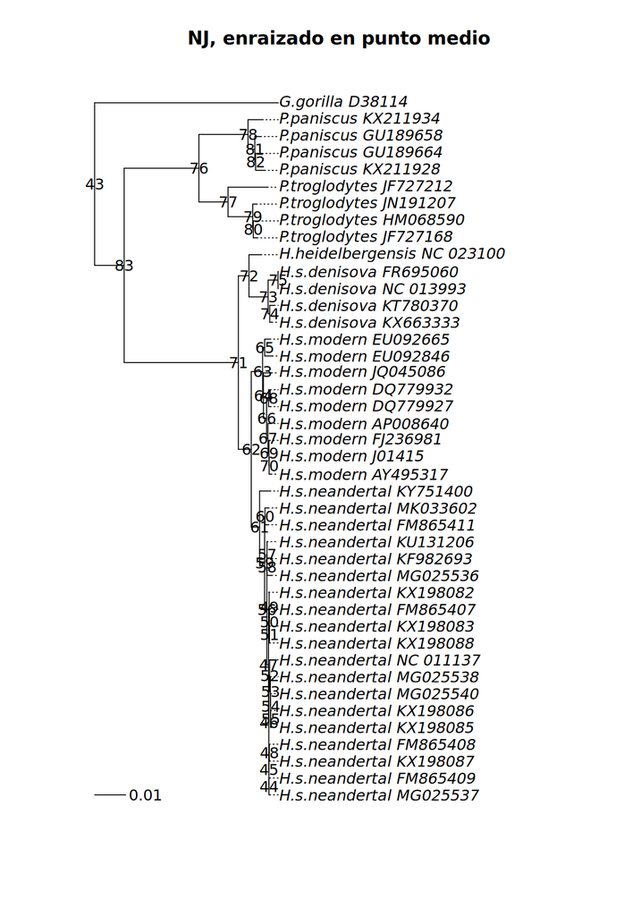

```r
mt_nj_rooted_mid <- midpoint(mt_nj)
plot(mt_nj_rooted_mid, align.tip.label = TRUE, main = 'NJ, enraizado en punto medio')
nodelabels(frame = 'none')
add.scale.bar()
```

## Con datación de hojas

Lo primero es crear un vector de fechas (o edades) para todas las hojas del árbol. Podemos expressar las edades de las secuencias arcaicas como el número (negativo) de años que hace que dejaron de evolucionar. Para saber el orden en que debemos especificar las edades, podemos usar mt_nj$tip.label.

```r
fechas <- c(0, 0, 0, 0, 0, 0, 0, 0, 0,
            -400000,
            -39000, -50000, -110000, -110000,
            -39820, -40096, -38515, -38310, -39000, -40000, -41210,
            -42430, -42540, -43230, -43780, -44290, -44770, -49000,
            -50000, -82752, -65000, -122287, -110450,
            0, 0, 0, 0, 0, 0, 0, 0, 0)
# Observa que hay que asignar el resultado de setNames() a "fechas"
fechas <- setNames(fechas, mt_nj$tip.label)
#He ocnsiderado innecesario y que carga mucho el documento añadir todas las tablas, así que no he representado "fechas"
```

A continuación se escoge la posición de la raíz que optimiza la regresión entre distancia de raíz a puntas y edades de las puntas (Rambaut et al. (2016)):

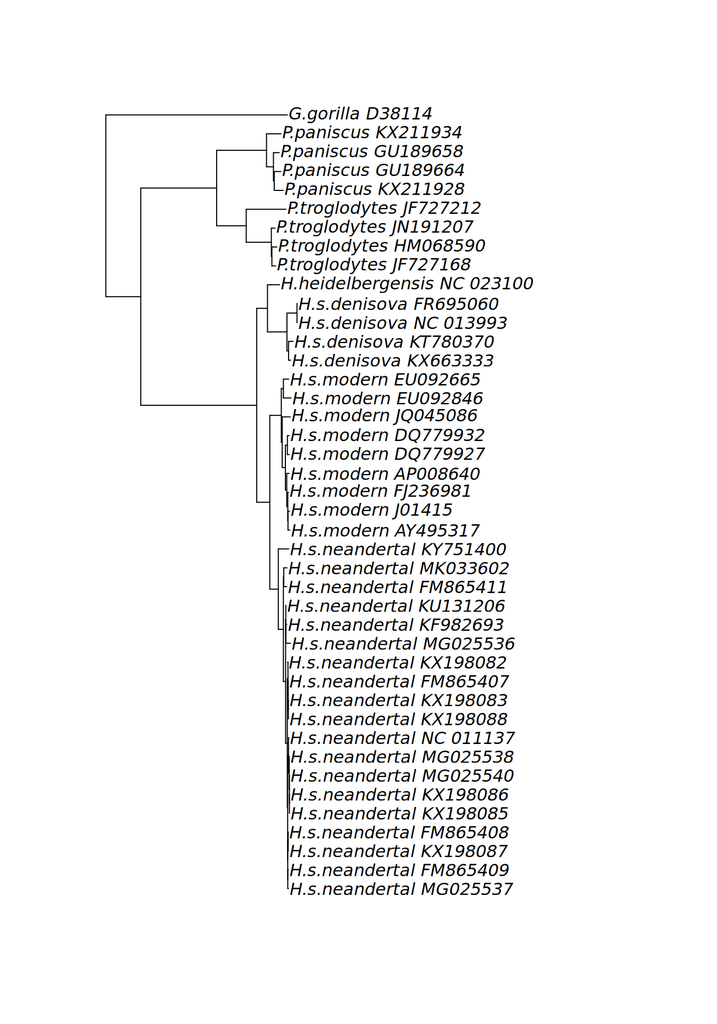

```r
mt_nj_rtt <- rtt(mt_nj, tip.dates = fechas, objective = 'rms')
plot(mt_nj_rtt)
```

**NotaEjercicio 3**

1. ¿Se corresponden bien las distancias evolutivas estimadas con las dataciones?
2. ¿Qué secuencias crees que se ajustan menos a su supuesta edad?
3. ¿Qué razones puede haber para que la edad de una secuencia no se corresponda con la cantidad de cambios que ha acumulado

**NotaSolución 3**

1. Para poder contestar a eso, primero debemos de hacer un ajuste de regresión para ver si nuestras secuencias más recientes se corresponden o no a una mayor distancia génica a la raíz.

```r
#Copiado de Gémini tal cual
distancias_rtt <- node.depth.edgelength(mt_nj_rtt)[1:length(mt_nj_rtt$tip.label)]
ajuste <- lm(distancias_rtt ~ fechas)
summary(ajuste)
```

```
Call:
lm(formula = distancias_rtt ~ fechas)

Residuals:
       Min         1Q     Median         3Q        Max
-0.0039189 -0.0001614  0.0003441  0.0006763  0.0031373

Coefficients:
             Estimate Std. Error t value Pr(>|t|)
(Intercept) 5.754e-02  2.807e-04 205.015   <2e-16 ***
fechas      5.677e-10  3.611e-09   0.157    0.876
---
Signif. codes:  0 '***' 0.001 '**' 0.01 '*' 0.05 '.' 0.1 ' ' 1

Residual standard error: 0.001544 on 40 degrees of freedom
Multiple R-squared:  0.0006173, Adjusted R-squared:  -0.02437
F-statistic: 0.02471 on 1 and 40 DF,  p-value: 0.8759
```

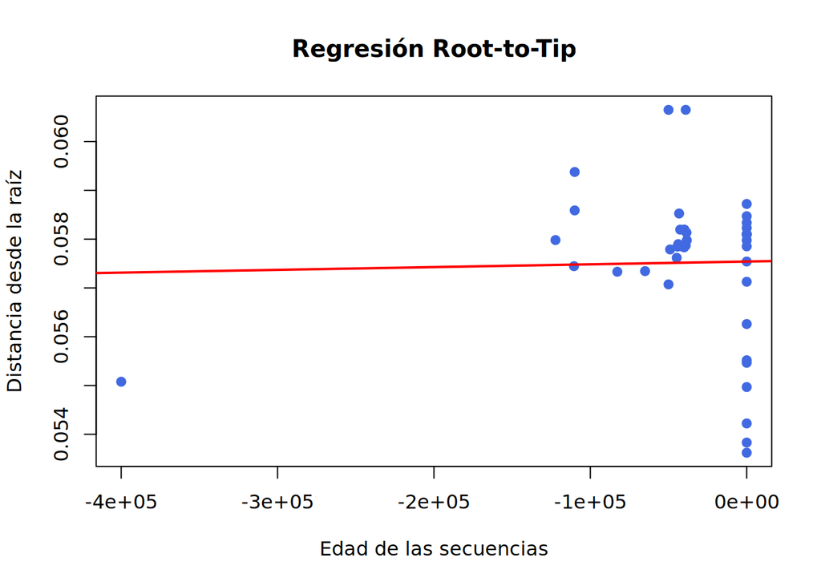

```r
plot(fechas, distancias_rtt,
     xlab = "Edad de las secuencias",
     ylab = "Distancia desde la raíz",
     main = "Regresión Root-to-Tip",
     pch = 19, col = "royalblue")

abline(ajuste, col = "red", lwd = 2)
```

# Distancias

Como hemos creado el objeto distancias antes, lo vamos a usar para conocer la cantidad estimada de cambios entre los cromosomas mitocondriales humanos y de neandertales, por ejemplo. El objeto de clase dist es incómodo, pero podemos obtener una simple matriz fácilmente:

```r
distMat <- as.matrix(distancias)
```

Aprovechando que los nombres de las secuencias tienen una estructura coherente, podemos usar `startsWith()` para seleccionar a los humanos modernos o a los neandertales, etc.:

```r
modernos     <- startsWith(colnames(distMat), 'H.s.modern')
neandertales <- startsWith(colnames(distMat), 'H.s.neandertal')
denisovanos  <- startsWith(colnames(distMat), 'H.s.denisova')
chimpances   <- startsWith(colnames(distMat), 'P.troglodytes')
bonobos      <- startsWith(colnames(distMat), 'P.paniscus')
```

La distancia estimada media entre humanos y neandertales se puede obtener como:

```r
mean(distMat[modernos, neandertales])
```

```
[1] 0.01214282
```

## Bibliografía

Rambaut, Andrew, Tommy T. Lam, Luiz Max Carvalho, y Oliver G. Pybus. 2016. «Exploring the temporal structure of heterochronous sequences using TempEst (formerly Path-O-Gen)». *Virus Evolution* 2 (1): vew007. https://doi.org/10.1093/ve/vew007.